# Building Models

**From EDA it is clear that data consists of Multi-Collinear features. Linear regression works really nicely when the data has a linear shape. But, when the data has a non-linear shape, then a linear model cannot capture the non-linear features. So in this case, you can use the trees based models, which do a better job at capturing the non-linearity in the data by dividing the space into smaller sub-spaces.**

## Importing Libraries

```python
import pandas as pd
import numpy as np
import matplotlib.pyplot as plt

from sklearn.metrics import mean_squared_error

import warnings
warnings.filterwarnings("ignore")
```

# Loading Data

```python
raw_data = pd.read_csv('propulsion.csv')
data = raw_data.copy()
data = data.drop('Unnamed: 0', axis = 1)
```

```python
data.head(5)
```

|  | Lever position (lp) [ ] | Ship speed (v) [knots] | Gas Turbine shaft torque (GTT) [kN m] | Gas Turbine rate of revolutions (GTn) [rpm] | Gas Generator rate of revolutions (GGn) [rpm] | Starboard Propeller Torque (Ts) [kN] | Port Propeller Torque (Tp) [kN] | HP Turbine exit temperature (T48) [C] | GT Compressor inlet air temperature (T1) [C] | GT Compressor outlet air temperature (T2) [C] | HP Turbine exit pressure (P48) [bar] | GT Compressor inlet air pressure (P1) [bar] | GT Compressor outlet air pressure (P2) [bar] | Gas Turbine exhaust gas pressure (Pexh) [bar] | Turbine Injecton Control (TIC) [%] | Fuel flow (mf) [kg/s] | GT Compressor decay state coefficient. | GT Turbine decay state coefficient. |
| --- | --- | --- | --- | --- | --- | --- | --- | --- | --- | --- | --- | --- | --- | --- | --- | --- | --- | --- |
| 0 | 9.300 | 27.0 | 72762.205 | 3560.393 | 9753.812 | 644.806 | 644.806 | 1086.583 | 288.0 | 780.304 | 4.523 | 0.998 | 22.879 | 1.050 | 90.435 | 1.790 | 0.973 | 0.978 |
| 1 | 6.175 | 18.0 | 29760.552 | 2306.825 | 8780.012 | 246.011 | 246.011 | 776.921 | 288.0 | 665.511 | 2.518 | 0.998 | 13.438 | 1.030 | 34.596 | 0.685 | 0.995 | 0.975 |
| 2 | 3.144 | 9.0 | 8375.774 | 1386.739 | 7051.621 | 60.318 | 60.318 | 589.764 | 288.0 | 580.587 | 1.392 | 0.998 | 7.566 | 1.020 | 12.477 | 0.247 | 0.980 | 0.978 |
| 3 | 3.144 | 9.0 | 8377.589 | 1386.748 | 7098.469 | 60.339 | 60.339 | 570.651 | 288.0 | 576.565 | 1.390 | 0.998 | 7.409 | 1.021 | 11.678 | 0.231 | 0.984 | 1.000 |
| 4 | 6.175 | 18.0 | 29761.091 | 2306.825 | 8782.024 | 246.021 | 246.021 | 769.855 | 288.0 | 663.682 | 2.518 | 0.998 | 13.374 | 1.031 | 34.154 | 0.676 | 0.998 | 0.980 |

```python
data.info()
```

```
<class 'pandas.core.frame.DataFrame'>
RangeIndex: 10000 entries, 0 to 9999
Data columns (total 18 columns):
 #   Column                                         Non-Null Count  Dtype
---  ------                                         --------------  -----
 0   Lever position (lp) [ ]                        10000 non-null  float64
 1   Ship speed (v) [knots]                         10000 non-null  float64
 2   Gas Turbine shaft torque (GTT) [kN m]          10000 non-null  float64
 3   Gas Turbine rate of revolutions (GTn) [rpm]    10000 non-null  float64
 4   Gas Generator rate of revolutions (GGn) [rpm]  10000 non-null  float64
 5   Starboard Propeller Torque (Ts) [kN]           10000 non-null  float64
 6   Port Propeller Torque (Tp) [kN]                10000 non-null  float64
 7   HP Turbine exit temperature (T48) [C]          10000 non-null  float64
 8   GT Compressor inlet air temperature (T1) [C]   10000 non-null  float64
 9   GT Compressor outlet air temperature (T2) [C]  10000 non-null  float64
 10  HP Turbine exit pressure (P48) [bar]           10000 non-null  float64
 11  GT Compressor inlet air pressure (P1) [bar]    10000 non-null  float64
 12  GT Compressor outlet air pressure (P2) [bar]   10000 non-null  float64
 13  Gas Turbine exhaust gas pressure (Pexh) [bar]  10000 non-null  float64
 14  Turbine Injecton Control (TIC) [%]             10000 non-null  float64
 15  Fuel flow (mf) [kg/s]                          10000 non-null  float64
 16  GT Compressor decay state coefficient.         10000 non-null  float64
 17  GT Turbine decay state coefficient.            10000 non-null  float64
dtypes: float64(18)
memory usage: 1.4 MB
```

## Splitting training, validation and test datasets

```python
x = data.drop(["GT Compressor decay state coefficient.", "GT Turbine decay state coefficient."], axis = 1)
y = data['GT Compressor decay state coefficient.']
```

```python
from sklearn.model_selection import train_test_split

#Training and test sets
x_train, x_test, y_train, y_test = train_test_split(x, y, test_size = 0.1, random_state = 42)

#Training and validation sets
x_train, x_val, y_train, y_val = train_test_split(x_train, y_train, test_size = 0.1, random_state = 42)

print("Training set shape: ", x_train.shape, y_train.shape)
print("Validation set shape: ", x_val.shape, y_val.shape)
print("Test set shape: ", x_test.shape, y_test.shape)
```

```
Training set shape:  (8100, 16) (8100,)
Validation set shape:  (900, 16) (900,)
Test set shape:  (1000, 16) (1000,)
```

# Scaling the data

```python
from sklearn.preprocessing import StandardScaler
scaler = StandardScaler()

x_train_scaled = scaler.fit_transform(x_train)
x_val_scaled = scaler.transform(x_val)
x_test_scaled = scaler.transform(x_test)
```

# Model creation and evaluation

The following ML models will be evaluated for this dataset.

```
1. Linear regression

2. Random Forest

3. K-Nearest neighbours

4. Support Vector Machine

5. XGBoost

6. Light GBM(LGBM)

7. CatBoost
```

At first, let's create a DataFrame that will store the validation results of all the models so that it can be compared later on.

```python
Results = pd.DataFrame(columns = ['Model', 'Validation Score(Before tuning)', 'Validation Score(After tuning)' ])
```

#### 1. Linear Regression

```python
from sklearn.linear_model import LinearRegression

lr =  LinearRegression()

lr.fit(x_train_scaled, y_train) #Fitting or training the data

y_val_pred = lr.predict(x_val_scaled)#Predicting on validation set

rmse = np.sqrt(mean_squared_error(y_val, y_val_pred)) #Evaluating model rmse score by comparing actual and predicted results

print("RMSE score: ", rmse)
```

```
RMSE score:  0.005947383942028075
```

```python
def plot_output(yact, yhat, name):
    plt.rcParams["figure.figsize"] = (15,6)
    fig, ax = plt.subplots(1,3)

    ax[0].scatter(yact, yhat)
    ax[0].axline([min(yact),min(yact)], [max(yact), max(yact)], color='r')
    ax[0].set_title("Actual vs Predicted")
    ax[0].set_xlabel("Predicted")
    ax[0].set_ylabel("Actual")

    ax[1].scatter(range(len(yact)), yhat-yact)
    ax[1].axhline(y=0, color='r', linestyle='-')
    ax[1].set_title("Residual Error")

    ax[2].boxplot([yact, yhat])
    ax[2].set_xticklabels(['Actaul', 'Predicted'])
    plt.suptitle(name)

    plt.show()
```

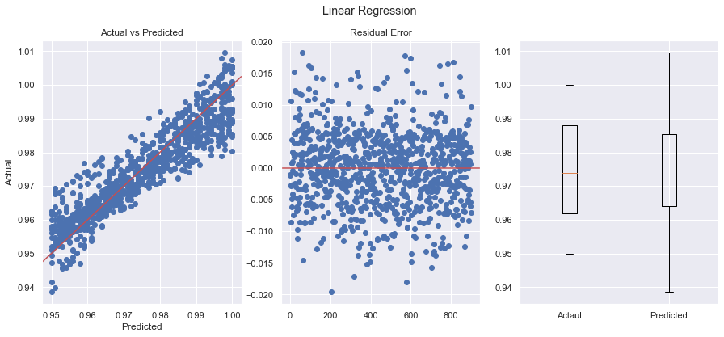

```python
plot_output(y_val, y_val_pred, 'Linear Regression')
```

```python
Results = Results.append({'Model' : 'Linear Regression', 'Validation Score(Before tuning)': rmse}, ignore_index = True)
Results
```

|  | Model | Validation Score(Before tuning) | Validation Score(After tuning) |
| --- | --- | --- | --- |
| 0 | Linear Regression | 0.005947 | NaN |

#### 2. Random Forest

```python
from sklearn.ensemble import RandomForestRegressor

rf = RandomForestRegressor()

rf.fit(x_train_scaled, y_train) #Fitting or training the data

y_val_pred = rf.predict(x_val_scaled) #Predicting on validation set

rmse = np.sqrt(mean_squared_error(y_val, y_val_pred)) #Evaluating model rmse score by comparing actual and predicted results


print("RMSE score: ", rmse)
```

```
RMSE score:  0.0013090178676311924
```

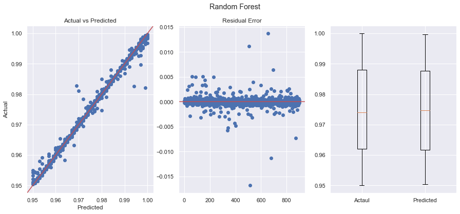

```python
plot_output(y_val, y_val_pred, 'Random Forest')
```

```python
Results = Results.append({'Model' : 'Random Forest', 'Validation Score(Before tuning)': rmse}, ignore_index = True)
Results
```

|  | Model | Validation Score(Before tuning) | Validation Score(After tuning) |
| --- | --- | --- | --- |
| 0 | Linear Regression | 0.005947 | NaN |
| 1 | Random Forest | 0.001309 | NaN |

#### 3. K Nearest Neighbours

```python
from sklearn.neighbors import KNeighborsRegressor

knn = KNeighborsRegressor()

knn.fit(x_train_scaled, y_train) #Fitting or training the data

y_val_pred = knn.predict(x_val_scaled) #Predicting on validation set

rmse = np.sqrt(mean_squared_error(y_val, y_val_pred)) #Evaluating model rmse score by comparing actual and predicted results

print("RMSE score: ", rmse)
```

```
RMSE score:  0.0018707693010571304
```

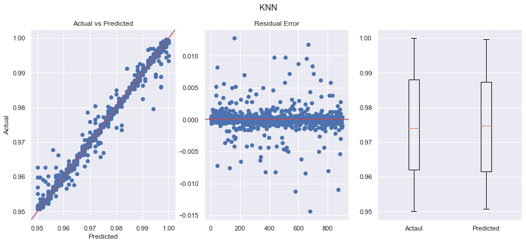

```python
plot_output(y_val, y_val_pred, 'KNN')
```

```python
Results = Results.append({'Model' : 'K Nearest Neighbours', 'Validation Score(Before tuning)': rmse}, ignore_index = True)
Results
```

|  | Model | Validation Score(Before tuning) | Validation Score(After tuning) |
| --- | --- | --- | --- |
| 0 | Linear Regression | 0.005947 | NaN |
| 1 | Random Forest | 0.001309 | NaN |
| 2 | K Nearest Neighbours | 0.001871 | NaN |

#### 4. Support Vector machine

```python
from sklearn.svm import SVR

svr = SVR()

svr.fit(x_train_scaled, y_train) #Fitting or training the data

y_val_pred = svr.predict(x_val_scaled) #Predicting on validation set

rmse = np.sqrt(mean_squared_error(y_val, y_val_pred)) #Evaluating model rmse score by comparing actual and predicted results

print("RMSE score: ", rmse)
```

```
RMSE score:  0.01488757871515716
```

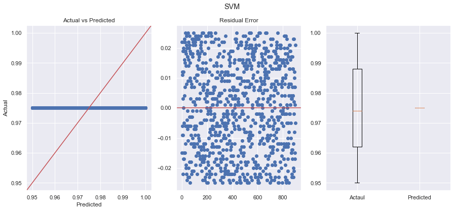

```python
plot_output(y_val, y_val_pred, 'SVM')
```

```python
Results = Results.append({'Model' : 'Support Vector Machine', 'Validation Score(Before tuning)': rmse}, ignore_index = True)
Results
```

|  | Model | Validation Score(Before tuning) | Validation Score(After tuning) |
| --- | --- | --- | --- |
| 0 | Linear Regression | 0.005947 | NaN |
| 1 | Random Forest | 0.001309 | NaN |
| 2 | K Nearest Neighbours | 0.001871 | NaN |
| 3 | Support Vector Machine | 0.014888 | NaN |

#### 5. XGBoost

```python
from xgboost import XGBRegressor

xgb = XGBRegressor()

xgb.fit(x_train_scaled, y_train) #Fitting or training the data

y_val_pred = xgb.predict(x_val_scaled) #Predicting on validation set

rmse = np.sqrt(mean_squared_error(y_val, y_val_pred)) #Evaluating model rmse score by comparing actual and predicted results

print("RMSE score: ", rmse)
```

```
RMSE score:  0.0013968312915578162
```

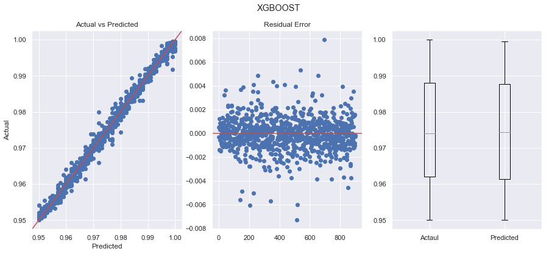

```python
plot_output(y_val, y_val_pred, 'XGBOOST')
```

```python
Results = Results.append({'Model' : 'XGBoost', 'Validation Score(Before tuning)': rmse}, ignore_index = True)
Results
```

|  | Model | Validation Score(Before tuning) | Validation Score(After tuning) |
| --- | --- | --- | --- |
| 0 | Linear Regression | 0.005947 | NaN |
| 1 | Random Forest | 0.001309 | NaN |
| 2 | K Nearest Neighbours | 0.001871 | NaN |
| 3 | Support Vector Machine | 0.014888 | NaN |
| 4 | XGBoost | 0.001397 | NaN |

#### 6. Light GBM (LGBM)

```python
from lightgbm import LGBMRegressor

lgbr = LGBMRegressor()

lgbr.fit(x_train_scaled, y_train) #Fitting or training the data

y_val_pred = lgbr.predict(x_val_scaled) #Predicting on validation set

rmse = np.sqrt(mean_squared_error(y_val, y_val_pred)) #Evaluating model rmse score by comparing actual and predicted results

print("RMSE score: ", rmse)
```

```
RMSE score:  0.0014111625482937703
```

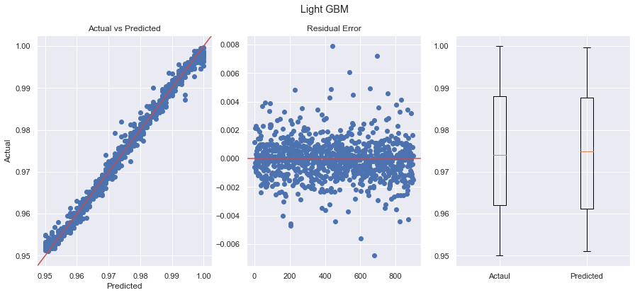

```python
plot_output(y_val, y_val_pred, 'Light GBM')
```

```python
Results = Results.append({'Model' : 'Light GBM', 'Validation Score(Before tuning)': rmse}, ignore_index = True)
Results
```

|  | Model | Validation Score(Before tuning) | Validation Score(After tuning) |
| --- | --- | --- | --- |
| 0 | Linear Regression | 0.005947 | NaN |
| 1 | Random Forest | 0.001309 | NaN |
| 2 | K Nearest Neighbours | 0.001871 | NaN |
| 3 | Support Vector Machine | 0.014888 | NaN |
| 4 | XGBoost | 0.001397 | NaN |
| 5 | Light GBM | 0.001411 | NaN |

#### 7. CatBoost

```python
from catboost import CatBoostRegressor

cb = CatBoostRegressor()

cb.fit(x_train_scaled, y_train, early_stopping_rounds = 10, verbose=200, plot = True) #Fitting or training the data

y_val_pred = cb.predict(x_val_scaled) #Predicting on validation set

rmse = np.sqrt(mean_squared_error(y_val, y_val_pred)) #Evaluating model rmse score by comparing actual and predicted results

print("RMSE score: ", rmse)
```

```
Learning rate set to 0.05698
0:	learn: 0.0143754	total: 2.82ms	remaining: 2.82s
200:	learn: 0.0030398	total: 324ms	remaining: 1.29s
400:	learn: 0.0018300	total: 659ms	remaining: 984ms
600:	learn: 0.0013201	total: 980ms	remaining: 651ms
800:	learn: 0.0010496	total: 1.31s	remaining: 325ms
999:	learn: 0.0008880	total: 1.64s	remaining: 0us
RMSE score:  0.0011412832822387477
```

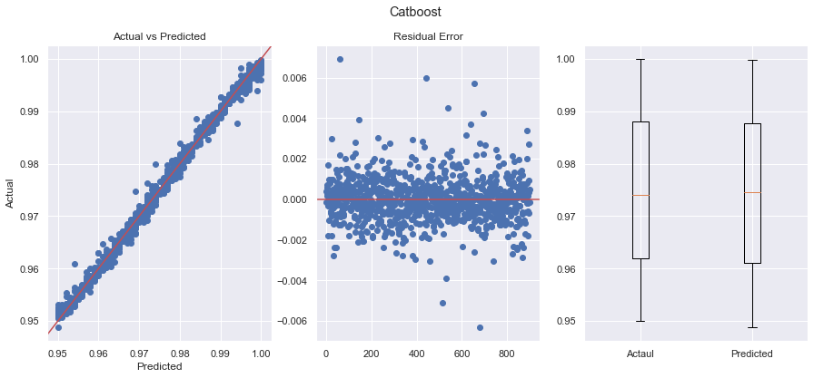

```python
plot_output(y_val, y_val_pred, 'Catboost')
```

```python
Results = Results.append({'Model' : 'CatBoost', 'Validation Score(Before tuning)': rmse}, ignore_index = True)
Results
```

|  | Model | Validation Score(Before tuning) | Validation Score(After tuning) |
| --- | --- | --- | --- |
| 0 | Linear Regression | 0.005947 | NaN |
| 1 | Random Forest | 0.001309 | NaN |
| 2 | K Nearest Neighbours | 0.001871 | NaN |
| 3 | Support Vector Machine | 0.014888 | NaN |
| 4 | XGBoost | 0.001397 | NaN |
| 5 | Light GBM | 0.001411 | NaN |
| 6 | CatBoost | 0.001141 | NaN |

# Results after using default model parameters

[output not shown]

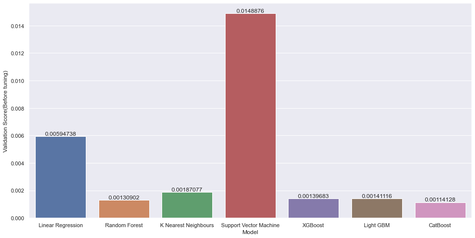

```python
import seaborn as sns
sns.set_theme(style="whitegrid")
sns.set(rc={'figure.figsize':(16,8)})
ax = sns.barplot(x="Model", y="Validation Score(Before tuning)", data=Results)
ax.bar_label(ax.containers[0])
```

## Hyper Parameter Tuning

#### For this we will use GridSearchCV

Grid search is the process of performing hyper parameter tuning in order to determine the optimal values for a given model. This is significant as the performance of the entire model is based on the hyper parameter values specified.

```python
from sklearn.model_selection import GridSearchCV

#Defining a function that will calculate the best parameters and RMSE score of the model based on those parameters
#Using GridSearchCV

def grid_search(regressor,parameters):

    grid = GridSearchCV(estimator = regressor, #The model object
                        param_grid = parameters, #The dictionary of parameteres to be searched on
                        scoring = 'neg_root_mean_squared_error', #Scoring method
                        cv = 5, #Cross-validation splits value
                        n_jobs = -1 #Number of CPU cores to be used, -1 means all cores to be used
                        )

    grid.fit(x_train_scaled,y_train) #Training the model

    print('Best parameters: ', grid.best_params_) #Displaying the best parameters of the model

    print("RMSE: ", (grid.best_score_))#RMSE score of the model based on those parameters
```

#### 1. Linear regression

```python
from sklearn.linear_model import LinearRegression

param_lr = {
    'normalize': [True, False],#"True":The regressors of X will be normalized by subtracting with mean and diving by l2 norm
    }

lr = LinearRegression()
grid_search(lr,param_lr)
```

```
Best parameters:  {'normalize': False}
RMSE:  -0.0058517726124968795
```

```python
#Retraining model with best parameters

lr =  LinearRegression(normalize = True)

lr.fit(x_train_scaled, y_train)

y_val_pred = lr.predict(x_val_scaled)

rmse = np.sqrt(mean_squared_error(y_val, y_val_pred))

print("RMSE score: ", rmse)
```

```
RMSE score:  0.005947383942028081
```

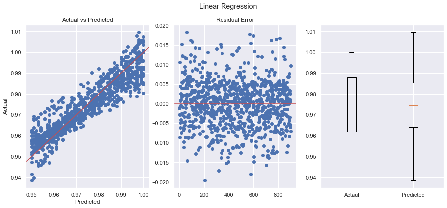

```python
plot_output(y_val, y_val_pred, 'Linear Regression')
```

```python
Results['Validation Score(After tuning)'][0] = rmse
Results
```

|  | Model | Validation Score(Before tuning) | Validation Score(After tuning) |
| --- | --- | --- | --- |
| 0 | Linear Regression | 0.005947 | 0.005947 |
| 1 | Random Forest | 0.001309 | NaN |
| 2 | K Nearest Neighbours | 0.001871 | NaN |
| 3 | Support Vector Machine | 0.014888 | NaN |
| 4 | XGBoost | 0.001397 | NaN |
| 5 | Light GBM | 0.001411 | NaN |
| 6 | CatBoost | 0.001141 | NaN |

#### 2. Random forest

```python
from sklearn.ensemble import RandomForestRegressor

param_rf = {
    'max_depth': [10, 20, 30], #max_depth determines the maximum height of each tree
    'n_estimators': [100, 200, 500] #The number of trees in the forest.
    }

rf = RandomForestRegressor()
grid_search(rf,param_rf)
```

```
Best parameters:  {'max_depth': 30, 'n_estimators': 200}
RMSE:  -0.001243729785549478
```

```python
#Retraining model with best parameters

rf = RandomForestRegressor(max_depth = 30, n_estimators = 500)

rf.fit(x_train_scaled, y_train)

y_val_pred = rf.predict(x_val_scaled)

rmse = np.sqrt(mean_squared_error(y_val, y_val_pred))

print("RMSE score: ", rmse)
```

[output not shown]

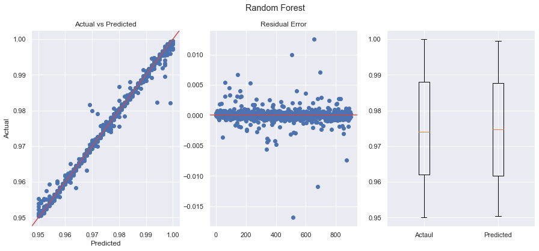

```python
plot_output(y_val, y_val_pred, 'Random Forest')
```

```python
Results['Validation Score(After tuning)'][1] = rmse
Results
```

[output not shown]

#### 3. K Nearest neighbours

```python
from sklearn.neighbors import KNeighborsRegressor

param_knn = {
    'leaf_size': [10, 15, 20, 50], #Leaf size affect the speed of the construction and query,
                                   #as well as the memory required to store the tree.
    'n_neighbors': list(range(1,10)), #Number of neighbouring points to consider
    'p': [1,2] #p = 1 for manhattan_distance, p = 2 for euclidean distance
    }

knn = KNeighborsRegressor()
grid_search(knn,param_knn)
```

```
Best parameters:  {'leaf_size': 10, 'n_neighbors': 2, 'p': 1}
RMSE:  -0.0017097438928533968
```

```python
#Retraining model with best parameters

knn = KNeighborsRegressor(leaf_size = 10, n_neighbors = 2, p = 1)

knn.fit(x_train_scaled, y_train)

y_val_pred = knn.predict(x_val_scaled)

rmse = np.sqrt(mean_squared_error(y_val, y_val_pred))

print("RMSE score: ", rmse)
```

```
RMSE score:  0.0014923880937015763
```

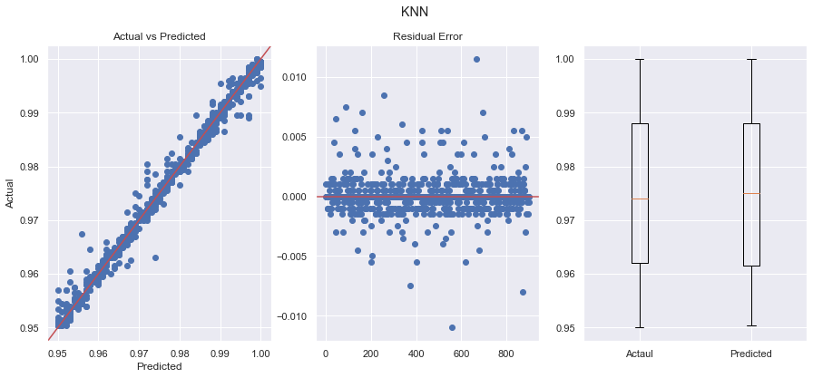

```python
plot_output(y_val, y_val_pred, 'KNN')
```

```python
Results['Validation Score(After tuning)'][2] = rmse
Results
```

|  | Model | Validation Score(Before tuning) | Validation Score(After tuning) |
| --- | --- | --- | --- |
| 0 | Linear Regression | 0.005947 | 0.005947 |
| 1 | Random Forest | 0.001309 | 0.001299 |
| 2 | K Nearest Neighbours | 0.001871 | 0.001492 |
| 3 | Support Vector Machine | 0.014888 | NaN |
| 4 | XGBoost | 0.001397 | NaN |
| 5 | Light GBM | 0.001411 | NaN |
| 6 | CatBoost | 0.001141 | NaN |

#### 4. Support vector Machine

```python
from sklearn.svm import SVR

param_svr = {
    'C': [0.1, 1, 10, 100, 1000],  #Regularization parameter. Must be positive
    'gamma': [1, 0.1, 0.01, 0.001, 0.0001], #Kernel Coefficient value
    'kernel': ['rbf', 'linear', 'poly'] #kernel type to be used in the algorithm
    }

svr = SVR()
grid_search(svr,param_svr)
```

```
Best parameters:  {'C': 0.1, 'gamma': 1, 'kernel': 'rbf'}
RMSE:  -0.014706150378339944
```

```python
#Retraining model with best parameters

svr = SVR(C = 0.1, gamma = 1, kernel = 'rbf')

svr.fit(x_train_scaled, y_train)

y_val_pred = svr.predict(x_val_scaled)

rmse = np.sqrt(mean_squared_error(y_val, y_val_pred))

print("RMSE score: ", rmse)
```

```
RMSE score:  0.01488757871515716
```

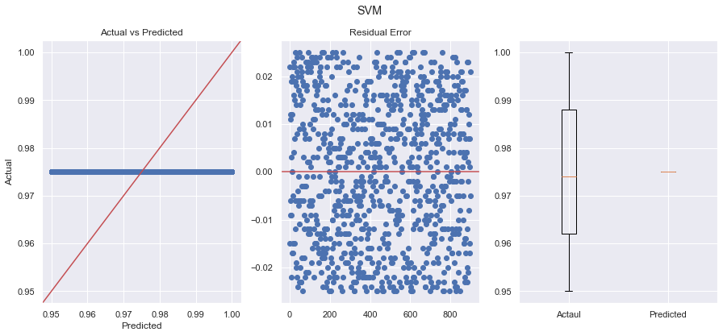

```python
plot_output(y_val, y_val_pred, 'SVM')
```

```python
Results['Validation Score(After tuning)'][3] = rmse
Results
```

|  | Model | Validation Score(Before tuning) | Validation Score(After tuning) |
| --- | --- | --- | --- |
| 0 | Linear Regression | 0.005947 | 0.005947 |
| 1 | Random Forest | 0.001309 | 0.001299 |
| 2 | K Nearest Neighbours | 0.001871 | 0.001492 |
| 3 | Support Vector Machine | 0.014888 | 0.014888 |
| 4 | XGBoost | 0.001397 | NaN |
| 5 | Light GBM | 0.001411 | NaN |
| 6 | CatBoost | 0.001141 | NaN |

#### 5. XGBoost

```python
from xgboost import XGBRegressor

param_xgb = {
    "learning_rate"    : [0.03, 0.05, 0.10 ], #The learning rate of the algorithm
    "max_depth"        : [10, 12, 15], #Maximum height of the boosted trees
    "min_child_weight" : [ 1, 5, 7 ], #Minimum sum of instance weight(hessian) needed in a child.
    "gamma"            : [ 0.0, 0.1, 0.2], #Minimum loss reduction required to make a further partition on a leaf node
    }

xgb = XGBRegressor()
grid_search(xgb,param_xgb)
```

```
Best parameters:  {'gamma': 0.0, 'learning_rate': 0.1, 'max_depth': 15, 'min_child_weight': 1}
RMSE:  -0.001087903702455068
```

```python
#Retraining model with best parameters

xgb = XGBRegressor(learning_rate = 0.1, max_depth = 15, min_child_weight = 5, gamma = 0)

xgb.fit(x_train_scaled, y_train)

y_val_pred = xgb.predict(x_val_scaled)

rmse = np.sqrt(mean_squared_error(y_val, y_val_pred))

print("RMSE score: ", rmse)
```

```
RMSE score:  0.0011223939537622506
```

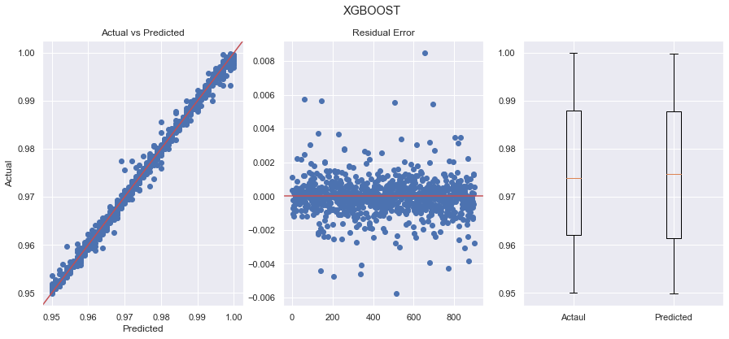

```python
plot_output(y_val, y_val_pred, 'XGBOOST')
```

```python
Results['Validation Score(After tuning)'][4] = rmse
Results
```

|  | Model | Validation Score(Before tuning) | Validation Score(After tuning) |
| --- | --- | --- | --- |
| 0 | Linear Regression | 0.005947 | 0.005947 |
| 1 | Random Forest | 0.001309 | 0.001299 |
| 2 | K Nearest Neighbours | 0.001871 | 0.001492 |
| 3 | Support Vector Machine | 0.014888 | 0.014888 |
| 4 | XGBoost | 0.001397 | 0.001122 |
| 5 | Light GBM | 0.001411 | NaN |
| 6 | CatBoost | 0.001141 | NaN |

#### 6. Light GBM

```python
from lightgbm import LGBMRegressor

param_lgb = {

    'learning_rate': [0.4, 0.2, 0.1, 0.01], #Learning rate of the algorithm
    'max_depth': [1, 5, 10, 12, 15], #Maximum height of trees
    'num_leaves': [10, 15, 20], #Maximum number of leaves for base learners
    'feature_fraction': [0.6,0.8], #Random fraction of features to be used while training
    'subsample': [0.2, 0.5], #Random fraction of records to be used while training
    }

lgb = LGBMRegressor(metric = 'RMSE')
grid_search(lgb,param_lgb)
```

[output not shown]

```python
#Retraining model with best parameters

lgbr = LGBMRegressor(feature_fraction = 0.8, learning_rate = 0.4, max_depth = 10, num_leaves = 20, subsample = 0.2)

lgbr.fit(x_train_scaled, y_train)

y_val_pred = lgbr.predict(x_val_scaled)

rmse = np.sqrt(mean_squared_error(y_val, y_val_pred))

print("RMSE score: ", rmse)
```

```
[LightGBM] [Warning] feature_fraction is set=0.8, colsample_bytree=1.0 will be ignored. Current value: feature_fraction=0.8
RMSE score:  0.0013619377824155494
```

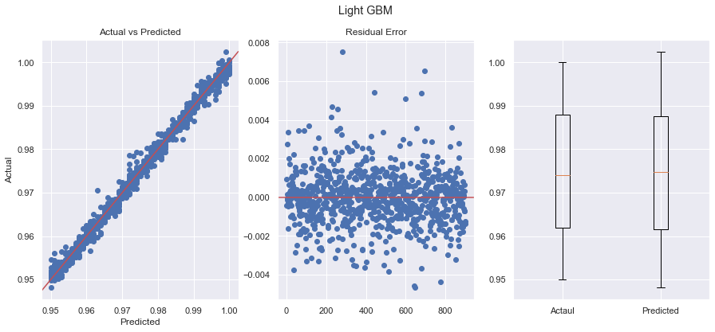

```python
plot_output(y_val, y_val_pred, 'Light GBM')
```

```python
Results['Validation Score(After tuning)'][5] = rmse
Results
```

|  | Model | Validation Score(Before tuning) | Validation Score(After tuning) |
| --- | --- | --- | --- |
| 0 | Linear Regression | 0.005947 | 0.005947 |
| 1 | Random Forest | 0.001309 | 0.001299 |
| 2 | K Nearest Neighbours | 0.001871 | 0.001492 |
| 3 | Support Vector Machine | 0.014888 | 0.014888 |
| 4 | XGBoost | 0.001397 | 0.001122 |
| 5 | Light GBM | 0.001411 | 0.001362 |
| 6 | CatBoost | 0.001141 | NaN |

#### 7. CatBoost

```python
from catboost import CatBoostRegressor

param_cb = {

    'learning_rate': [0.1, 0.05], #Learning rate of algorithm
    'depth': [5, 8], #Lower value prevents overfitting
    'bagging_temperature': [3, 10], #Helps to tackale overfitting
    'l2_leaf_reg' : [0.5, 1, 2] #Regularization term

    }

cb = CatBoostRegressor(early_stopping_rounds = 10, verbose = False)
grid_search(cb,param_cb)
```

[output not shown]

```python
from catboost import CatBoostRegressor

#Retraining model with best parameters

cb = CatBoostRegressor(bagging_temperature = 3, depth = 8, l2_leaf_reg = 0.5, learning_rate = 0.1)

cb.fit(x_train_scaled, y_train, early_stopping_rounds = 10, verbose=200, plot = False)

y_val_pred = cb.predict(x_val_scaled)

rmse = np.sqrt(mean_squared_error(y_val, y_val_pred))

print("RMSE score: ", rmse)
```

```
0:	learn: 0.0139915	total: 57.7ms	remaining: 57.6s
200:	learn: 0.0015150	total: 616ms	remaining: 2.45s
400:	learn: 0.0008696	total: 1.18s	remaining: 1.76s
600:	learn: 0.0006496	total: 1.73s	remaining: 1.15s
800:	learn: 0.0005358	total: 2.3s	remaining: 572ms
999:	learn: 0.0004647	total: 2.9s	remaining: 0us
RMSE score:  0.0008861841874832236
```

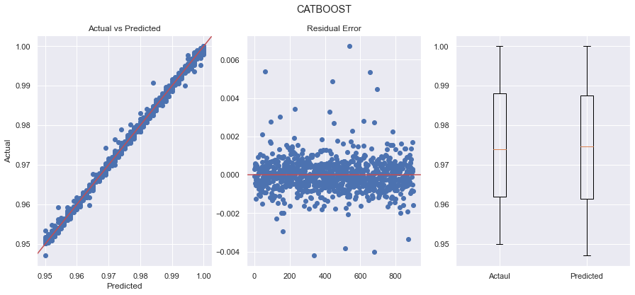

```python
plot_output(y_val, y_val_pred, 'CATBOOST')
```

```python
Results['Validation Score(After tuning)'][6] = rmse
Results
```

|  | Model | Validation Score(Before tuning) | Validation Score(After tuning) |
| --- | --- | --- | --- |
| 0 | Linear Regression | 0.005947 | 0.005947 |
| 1 | Random Forest | 0.001309 | 0.001299 |
| 2 | K Nearest Neighbours | 0.001871 | 0.001492 |
| 3 | Support Vector Machine | 0.014888 | 0.014888 |
| 4 | XGBoost | 0.001397 | 0.001122 |
| 5 | Light GBM | 0.001411 | 0.001362 |
| 6 | CatBoost | 0.001141 | 0.000886 |

## Feature Importance - CatBoost

```python
print('5 most important features : ')
[x_train.columns[i] for i in np.array(cb.get_feature_importance()).argsort()[-5:]]
```

```
5 most important features :
```

```
['Gas Turbine shaft torque (GTT) [kN m]',
 'GT Compressor outlet air temperature (T2) [C]',
 'Gas Generator rate of revolutions (GGn) [rpm]',
 'HP Turbine exit pressure (P48) [bar]',
 'Gas Turbine exhaust gas pressure (Pexh) [bar]']
```

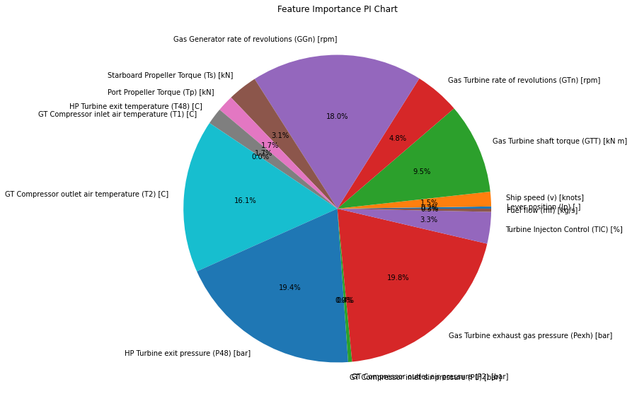

```python
# Creating plot
fig = plt.figure(figsize =(30, 10))
plt.pie(cb.get_feature_importance(), labels = x_train.columns, autopct='%1.1f%%')

# show plot
plt.title('Feature Importance PI Chart')
plt.show()
```

### Among all these models, CatBoost outperforms them all.**

### It is noteworthy to mention that **CatBoost** showed remarkable performance before hyper parameter tuning, and after tuning.

```python
df = pd.melt(Results, id_vars="Model", var_name="Type", value_name="Validation Scores")
```

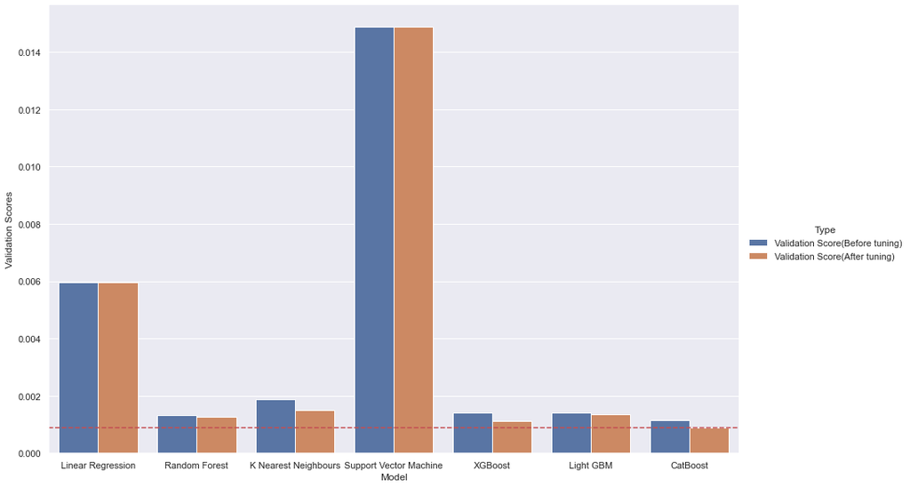

```python
sns.set_theme(style="whitegrid")
sns.set(rc={'figure.figsize':(50,30)})
sns.factorplot(x='Model', y='Validation Scores', hue='Type', data=df, kind='bar', height=8.27, aspect=12.7/8.27)
plt.axhline(y=0.000886, color='r', linestyle='--')
```

## Best Model - CatBoost

##### Let's test our test set on the CatBoost modelfor final evaluation

```python
y_test_pred = cb.predict(x_test_scaled) #Testing on test set

rmse = np.sqrt(mean_squared_error(y_test, y_test_pred)) #Evaluating model rmse score by comparing actual and predicted results

print("RMSE score: ", rmse)
```

```
RMSE score:  0.0008444527738886417
```

The RMSE score is amazing for the test set as well.

### Saving Scaler object

```python
#The scaler object needs to be saved for further use on new test sets

import pickle

filehandler = open('scaler_GT_Compressor.pickle', 'wb')
pickle.dump(scaler, filehandler)
filehandler.close()
```

### Saving the CatBoost model object

```python
#The best model object needs to saved in order to use it further in new test sets

import pickle

filehandler = open('CatBoostRegressor_GT_Compressor.pickle', 'wb')
pickle.dump(cb, filehandler)
filehandler.close()
```

### Saving the Model comparison data as csv file

```python
#Let's also save the model comparison data

Results.to_csv('Model_Comparison_GT_Compressor.csv')
```